# HAALSI Hackathon: Risk Factors for Cognitive Impairment

Waves 1-3 longitudinal analysis

Joshua Yeung

2026-10-24

# How to use this file

1. Download `HAALSI_W1-3_Longitudinal_Dataset.dta` from the HAALSI Harvard Dataverse and put it in the same folder as this file. The name must match exactly (rename it if your browser added something like `(1)` or `_2`).
2. Click **Knit**. The first run builds a cleaned dataset (`..._long.rds`); later runs reuse it.
3. **Data cleaning** and **About the data** are done for you. Read them, but don’t change them.
4. In each question, look for `___` (three underscores). Replace each one with code, then Knit again. Lines starting with `# HINT` tell you what goes there. Until you fill a blank, that chunk shows `Error: unexpected input` in the report. That’s expected. Later chunks that use your result will also show errors until the earlier blank is done.
5. Write your answers in the *Interpretation* lines under each question.
6. Do not submit or share the `.dta` or `.rds` files.

# 1 Data cleaning

This section reads the HAALSI file you downloaded from Harvard Dataverse, keeps the variables we need, recodes them and saves a cleaned file with one row per person per wave. It only runs if the cleaned file doesn’t exist yet, or if you render with `params = list(rebuild = TRUE)`.

**Coding rules used below:** −97 (refused), −98 (don’t know) and −99 (empty) are missing; yes/no variables are 1 = Yes, 2 = No and are recoded to 1/0; sex is 1 = Male, 2 = Female.

```r
dta_path <- params$data_path
rds_path <- paste0(tools::file_path_sans_ext(basename(dta_path)), "_long.rds")

if (params$rebuild || !file.exists(rds_path)) {
  if (!file.exists(dta_path)) {
    stop("Cannot find '", dta_path, "'. Download it from the HAALSI Harvard Dataverse, ",
         "put it in the same folder as this .Rmd file and check the file name matches exactly.")
  }

  # 1. Variables. "?" is replaced by the wave number.
  wave_vars <- c(
    age = "w?c_rage_calc", marital_status = "w?c_bd_mar", hhsize = "w?c_hhsize",
    hhnum = "w?c_hhnum", wealth = "w?c_wealthindex", asset = "w?c_hh_assetindex",
    employment = "w?c_ep_employed",
    memory = "w?cn001", concentration = "w?cn002", learning = "w?cn003",
    cesd = "w?c_cd_cesd", bmi = "w?c_bs_bmi", bmi_category = "w?c_bs_bmicat",
    hypertension_diag = "w?c_cm_hypertension_srdiag", htn_on_med_raw = "w?cm005",
    diabetes_diag = "w?c_cm_diabetes_srdiag", dm_on_med_raw = "w?cm010",
    adls_walk = "w?c_pf_diff_walk", adls_dress = "w?c_pf_diff_dress",
    adls_bath = "w?c_pf_diff_bath", adls_eat = "w?c_pf_diff_eat",
    adls_toilet = "w?c_pf_diff_toilet",
    systolic_bp = "w?c_bs_mean_sys", diastolic_bp = "w?c_bs_mean_dia", glucose = "w?c_bs_glucose",
    smoking = "w?cm059", alcohol = "w?cm068",
    status = "w?status", int_year = "w?c_int_year", int_month = "w?c_int_month",
    # cognition (Waves 2-3 have summary scores; Wave 1 is built from item-level data below)
    imrec1 = "w?c_cn_imrec1", delrec = "w?c_cn_delrec", orient_sum = "w?cn214"
  )
  fixed_vars <- c("w2c_rsex", "w1c_bd_educ4", "w1c_bd_country")
  w1_cog_items <- c("w1cn013", paste0("w1cn007s", 1:10), paste0("w1cn012s", 1:10),
                    paste0("w1cn01", 4:7))

  wanted <- c("prim_key", fixed_vars, w1_cog_items,
              unlist(lapply(1:3, function(w) sub("?", w, wave_vars, fixed = TRUE))))
  all_names <- names(read_dta(dta_path, n_max = 0))
  raw <- read_dta(dta_path, col_select = all_of(intersect(wanted, all_names)))
  raw <- zap_labels(zap_missing(raw))

  # 2. Helpers
  neg_to_na <- function(x) { x <- as.numeric(x); x[x < 0] <- NA; x }
  yes_no    <- function(x) { x <- as.numeric(x)
    case_when(x == 1 ~ 1, x %in% c(0, 2) ~ 0, TRUE ~ NA_real_) }

  # 3. Wave 1 cognition from item-level data.
  #    Word recall: one column per word, value > 0 = word recalled.
  #    Wave 1 had one immediate-recall trial, so trial 1 is used in every wave.
  w1_recall <- function(stem) {
    m <- as.matrix(raw[, paste0(stem, "s", 1:10)]); m[is.na(m)] <- 0
    n <- rowSums(m > 0)
    n[rowSums(m == -97) > 0] <- NA            # refused
    n[is.na(raw$w1cn013)] <- NA               # cognition section not done (e.g., proxy)
    n
  }
  orient_w1 <- sapply(paste0("w1cn01", 4:7), function(v) {
    x <- as.numeric(raw[[v]]); case_when(x == 1 ~ 1, x %in% c(2, -98) ~ 0, TRUE ~ NA_real_) })
  w1_cog <- tibble(prim_key = raw$prim_key, wave = 1,
                   imrec1_w1 = w1_recall("w1cn007"), delrec_w1 = w1_recall("w1cn012"),
                   orient_w1 = rowSums(orient_w1))

  # 4. Wide -> long
  long <- lapply(1:3, function(w) {
    cols <- sub("?", w, wave_vars, fixed = TRUE)
    out  <- tibble(prim_key = raw$prim_key, wave = w)
    for (nm in names(wave_vars)) {
      out[[nm]] <- if (cols[[nm]] %in% names(raw)) as.numeric(raw[[cols[[nm]]]]) else NA_real_
    }
    out
  }) |> bind_rows() |>
    left_join(w1_cog, by = c("prim_key", "wave")) |>
    mutate(imrec1     = if_else(wave == 1, imrec1_w1, imrec1),
           delrec     = if_else(wave == 1, delrec_w1, delrec),
           orient_sum = if_else(wave == 1, orient_w1, orient_sum)) |>
    select(-imrec1_w1, -delrec_w1, -orient_w1)

  fixed <- tibble(
    prim_key = raw$prim_key,
    sex = case_when(raw$w2c_rsex == 1 ~ 1, raw$w2c_rsex == 2 ~ 0),     # 1 = Male, 0 = Female
    education_category = neg_to_na(raw$w1c_bd_educ4),
    born_moz = case_when(raw$w1c_bd_country == 2 ~ 1, raw$w1c_bd_country == 1 ~ 0)
  )

  # 5. Recode
  long <- long |>
    left_join(fixed, by = "prim_key") |>
    mutate(
      status = if_else(wave == 1, 1, status),
      across(c(age, marital_status, hhsize, hhnum, wealth, employment, memory, concentration,
               learning, cesd, bmi, bmi_category, systolic_bp, diastolic_bp, glucose,
               imrec1, delrec, orient_sum), neg_to_na),
      employment = if_else(wave == 3 & employment == 0, 2, employment),
      across(c(hypertension_diag, diabetes_diag, smoking, alcohol, htn_on_med_raw,
               dm_on_med_raw), yes_no),
      across(starts_with("adls_"), ~ case_when(.x %in% c(1, 3) ~ 1, .x == 2 ~ 0, TRUE ~ NA_real_))
    )

  # 6. Derived variables
  long <- long |>
    mutate(
      htn_group = factor(case_when(hypertension_diag == 0 ~ "No hypertension",
                                   htn_on_med_raw == 1    ~ "Hypertension, treated",
                                   hypertension_diag == 1 ~ "Hypertension, untreated"),
                         levels = c("No hypertension", "Hypertension, untreated",
                                    "Hypertension, treated")),
      dm_group  = factor(case_when(diabetes_diag == 0 ~ "No diabetes",
                                   dm_on_med_raw == 1 ~ "Diabetes, treated",
                                   diabetes_diag == 1 ~ "Diabetes, untreated"),
                         levels = c("No diabetes", "Diabetes, untreated", "Diabetes, treated")),
      adl_count = adls_walk + adls_dress + adls_bath + adls_eat + adls_toilet,
      any_adl   = as.numeric(adl_count > 0),
      int_date  = int_year + (int_month - 0.5) / 12
    ) |>
    select(-htn_on_med_raw, -dm_on_med_raw)

  # Objective cognition: each test z-scored to Wave 1, averaged, re-standardized to Wave 1.
  ref <- filter(long, wave == 1)
  zref <- function(x, r) (x - mean(r, na.rm = TRUE)) / sd(r, na.rm = TRUE)
  long <- long |>
    mutate(cog_raw = (zref(orient_sum, ref$orient_sum) + zref(imrec1, ref$imrec1) +
                        zref(delrec, ref$delrec)) / 3)
  long <- long |>
    mutate(objective_cognition_z = zref(cog_raw, cog_raw[wave == 1])) |> select(-cog_raw)
  cut20 <- quantile(long$objective_cognition_z[long$wave == 1], 0.20, na.rm = TRUE)
  long  <- long |> mutate(low_cognition = as.numeric(objective_cognition_z < cut20))

  # Wealth: asset index in SD units (Wave 1 scale); CES-D z-scored within wave
  long <- long |>
    mutate(asset_sd = zref(asset, asset[wave == 1])) |>
    group_by(wave) |>
    mutate(cesd_z = (cesd - mean(cesd, na.rm = TRUE)) / sd(cesd, na.rm = TRUE)) |>
    ungroup()

  # Time since baseline (Wave 1) interview, in years
  long <- long |>
    group_by(prim_key) |>
    mutate(years_since_bl = int_date - int_date[wave == 1][1]) |>
    ungroup()

  # Labelled factors
  long <- long |>
    mutate(
      sex_f       = factor(sex, 0:1, c("Female", "Male")),
      education_f = factor(education_category, 1:4,
                           c("No formal", "Some primary", "Some secondary", "Secondary+")),
      marital_f   = factor(marital_status, 0:3,
                           c("Never married", "Separated/divorced", "Widowed", "Married")),
      hhsize_f    = factor(hhsize, 0:3, c("Alone", "2 people", "3-6 people", "7+ people")),
      wealth_f    = factor(wealth, 1:5, c("Q1 (poorest)", "Q2", "Q3", "Q4", "Q5 (richest)")),
      employment_f   = factor(employment, 1:3, c("Employed", "Not working", "Homemaker")),
      bmi_category_f = factor(bmi_category, 0:3, c("Underweight", "Normal", "Overweight", "Obese"))
    ) |>
    arrange(prim_key, wave)

  saveRDS(long, rds_path)
}

haalsi <- readRDS(rds_path)
cat(rds_path, ":", nrow(haalsi), "person-waves,", n_distinct(haalsi$prim_key), "participants\n")
```

```
## HAALSI_W1-3_Longitudinal_Dataset_long.rds : 15177 person-waves, 5059 participants
```

# 2 About the data

```r
haalsi |>
  group_by(wave) |>
  summarise(completed = sum(status == 1, na.rm = TRUE),
            with_cognition = sum(!is.na(objective_cognition_z)),
            mean_years_since_bl = round(mean(years_since_bl[status == 1], na.rm = TRUE), 1),
            mean_cognition = round(mean(objective_cognition_z, na.rm = TRUE), 2)) |>
  knitr::kable()
```

| wave | completed | with_cognition | mean_years_since_bl | mean_cognition |
| --- | --- | --- | --- | --- |
| 1 | 5059 | 4903 | 0.0 | 0.00 |
| 2 | 4176 | 3873 | 3.7 | 0.26 |
| 3 | 3707 | 3317 | 6.4 | 0.42 |

```r
w1 <- filter(haalsi, wave == 1) |> mutate(bmi_category_f = relevel(bmi_category_f, ref = "Normal"))

# Baseline (Wave 1) characteristics, used as predictors of change
baseline <- w1 |>
  transmute(prim_key, age_bl = age, age10_bl = (age - 60) / 10, sex_f, education_f, born_moz,
            marital_f, hhsize_bl_f = hhsize_f, wealth_bl = wealth, asset_sd_bl = asset_sd,
            employment_bl_f = employment_f, cesd_bl_z = cesd_z,
            htn_bl = hypertension_diag, htn_group_bl = htn_group, dm_bl = diabetes_diag,
            bmi_bl = bmi, bmi_cat_bl_f = bmi_category_f, smoking_bl = smoking, alcohol_bl = alcohol)

# One row per person per wave with cognition, plus baseline characteristics
cog_long <- haalsi |>
  filter(!is.na(objective_cognition_z), !is.na(years_since_bl)) |>
  select(prim_key, wave, years = years_since_bl, objective_cognition_z, low_cognition) |>
  left_join(baseline, by = "prim_key")

cat("Wave 1 sample:", nrow(w1), " | person-waves with cognition:", nrow(cog_long), "\n")
```

```
## Wave 1 sample: 5059  | person-waves with cognition: 12092
```

# 3 Question 1: Which intervention could have the greatest benefit?

## 3.1 1a. Is household wealth associated with cognition? (worked example)

This section is complete. Use it as a model for the rest of the questions.

**Confounders.** Age and sex influence wealth and cognition, and education comes before wealth in the life course. Avoid variables that wealth itself could change (BMI, hypertension, depression), since they may be mechanisms.

```r
# Level of cognition: wealth quintiles vs the poorest, and per SD of the asset index
m1a_cat <- lm(objective_cognition_z ~ wealth_f + age + sex_f + education_f, data = w1)
show_lm(m1a_cat, "wealth")
```

| term | estimate | conf.low | conf.high | p.value |
| --- | --- | --- | --- | --- |
| wealth_fQ2 | 0.091 | 0.016 | 0.167 | 0.017 |
| wealth_fQ3 | 0.176 | 0.100 | 0.253 | 0.000 |
| wealth_fQ4 | 0.198 | 0.121 | 0.274 | 0.000 |
| wealth_fQ5 (richest) | 0.306 | 0.226 | 0.386 | 0.000 |

```r
m1a_sd <- lm(objective_cognition_z ~ asset_sd + age + sex_f + education_f, data = w1)
show_lm(m1a_sd, "asset")
```

| term | estimate | conf.low | conf.high | p.value |
| --- | --- | --- | --- | --- |
| asset_sd | 0.11 | 0.084 | 0.136 | 0 |

```r
# Risk of low cognition: odds ratios
m1a_low <- glm(low_cognition ~ asset_sd + age + sex_f + education_f, family = binomial, data = w1)
show_glm(m1a_low, "asset")
```

| term | estimate | conf.low | conf.high | p.value |
| --- | --- | --- | --- | --- |
| asset_sd | 0.702 | 0.632 | 0.778 | 0 |

```r
# Rate of change: random intercept and slope per person.
# Covariates interact with time so they adjust the slope as well as the level.
m1a_slope <- lmer(objective_cognition_z ~ years * (asset_sd_bl + age10_bl + sex_f + education_f) +
                    (1 + years | prim_key), data = cog_long)
show_lmer(m1a_slope, "asset")
```

| term | estimate | conf.low | conf.high | p.value |
| --- | --- | --- | --- | --- |
| asset_sd_bl | 0.112 | 0.087 | 0.137 | 0.000 |
| years:asset_sd_bl | 0.002 | -0.004 | 0.007 | 0.543 |

*Interpretation:* Cognition rises steadily with wealth. Compared with the poorest quintile, Q2 scores 0.09 SD higher and the richest quintile 0.31 SD higher (95% CI 0.23 to 0.39), after age, sex and education. Each 1 SD of the asset index is worth 0.11 SD of cognition and lowers the odds of low cognition by about 30% (OR 0.70, 0.63 to 0.78). Wealth does not predict the rate of change (`years:asset_sd_bl` = 0.002 SD/year, CI -0.004 to 0.007): it is tied to the level of cognition, not how fast it changes over 6 years.

*Try:* add `log(hhnum)` (household size) or `marital_f`. Is each a confounder or a mediator?

## 3.2 1b. Is hypertension associated with cognition?

Compare no hypertension, untreated hypertension and treated hypertension (`htn_group`).

```r
# Level of cognition
# HINT: put the exposure where the ___ is. Which confounders? Is wealth a confounder here?
m1b <- lm(objective_cognition_z ~ htn_group + age + sex_f + education_f + wealth_f, data = w1)
show_lm(m1b, "htn")
```

| term | estimate | conf.low | conf.high | p.value |
| --- | --- | --- | --- | --- |
| htn_groupHypertension, untreated | 0.013 | -0.044 | 0.070 | 0.653 |
| htn_groupHypertension, treated | 0.160 | 0.097 | 0.222 | 0.000 |

```r
# Risk of low cognition
# HINT: outcome = low_cognition; logistic regression uses family = binomial
m1b_low <- glm(low_cognition ~ htn_group + age + sex_f + education_f + wealth_f, family = binomial, data = w1)
show_glm(m1b_low, "htn")
```

| term | estimate | conf.low | conf.high | p.value |
| --- | --- | --- | --- | --- |
| htn_groupHypertension, untreated | 1.012 | 0.835 | 1.226 | 0.905 |
| htn_groupHypertension, treated | 0.613 | 0.496 | 0.755 | 0.000 |

```r
# Rate of change
# HINT: copy m1a_slope above and replace asset_sd_bl with htn_group_bl
m1b_slope <- lmer(objective_cognition_z ~ years * (htn_group_bl + age10_bl + sex_f + education_f + asset_sd_bl) +
                    (1 + years | prim_key), data = cog_long)
show_lmer(m1b_slope, "htn")
```

| term | estimate | conf.low | conf.high | p.value |
| --- | --- | --- | --- | --- |
| htn_group_blHypertension, untreated | 0.023 | -0.032 | 0.078 | 0.407 |
| htn_group_blHypertension, treated | 0.165 | 0.105 | 0.225 | 0.000 |
| years:htn_group_blHypertension, untreated | -0.001 | -0.013 | 0.011 | 0.889 |
| years:htn_group_blHypertension, treated | -0.020 | -0.033 | -0.007 | 0.003 |

*Interpretation:* Untreated hypertension looks just like no hypertension (+0.01 SD, CI -0.04 to 0.07; OR 1.01). Treated hypertension scores 0.16 SD *higher* (CI 0.10 to 0.22), with lower odds of low cognition (OR 0.61, 0.50 to 0.76). That is very unlikely to be the pills alone. People who get diagnosed and treated are the ones who reach clinics, follow up and have the means and health literacy to do so (healthy-user and access-to-care confounding). Wealth and education only partly capture that. The treated group’s slope is slightly steeper (-0.020 SD/year, CI -0.033 to -0.007), consistent with regression to the mean from a higher starting point, not harm. This is not causal evidence that treatment protects cognition. The fair comparison would be a trial or a treatment-access natural experiment.

## 3.3 1c. Is depression associated with objective and subjective cognition?

All outcomes are standardized so the coefficients can be compared. For subjective outcomes a positive coefficient means more reported difficulty; for objective cognition a negative coefficient means worse performance.

```r
w1_std <- w1 |>
  mutate(across(c(objective_cognition_z, memory, concentration, learning),
                ~ as.numeric(scale(.x)), .names = "{.col}_std"))
outcomes <- c("objective_cognition_z_std", "memory_std", "concentration_std", "learning_std")
```

```r
q1c <- lapply(outcomes, function(y) {
  # HINT: the exposure is the standardized CES-D score. Use the same name in both blanks.
  f <- reformulate(c("cesd_z", "age", "sex_f", "education_f", "wealth_f"), response = y)
  tidy(lm(f, data = w1_std), conf.int = TRUE) |> filter(term == "cesd_z") |> mutate(outcome = y)
}) |> bind_rows()

q1c |> select(outcome, estimate, conf.low, conf.high, p.value) |>
  mutate(across(where(is.numeric), ~ round(.x, 3))) |> knitr::kable()
```

| outcome | estimate | conf.low | conf.high | p.value |
| --- | --- | --- | --- | --- |
| objective_cognition_z_std | -0.106 | -0.130 | -0.082 | 0 |
| memory_std | 0.198 | 0.172 | 0.224 | 0 |
| concentration_std | 0.183 | 0.156 | 0.210 | 0 |
| learning_std | 0.168 | 0.141 | 0.196 | 0 |

```r
# YOUR TURN: fit a logistic model of low_cognition on cesd_z (same covariates) and show the OR.
m1c_low <- glm(low_cognition ~ cesd_z + age + sex_f + education_f + wealth_f, family = binomial, data = w1)
show_glm(m1c_low, "cesd")
```

| term | estimate | conf.low | conf.high | p.value |
| --- | --- | --- | --- | --- |
| cesd_z | 1.263 | 1.172 | 1.361 | 0 |

*Interpretation:* A 1 SD higher CES-D score goes with 0.11 SD *lower* objective cognition but 0.17 to 0.20 SD *more* self-reported difficulty (memory 0.20, concentration 0.18, learning 0.17), so the subjective link is almost twice the objective one. Each SD of CES-D also raises the odds of low cognition by 26% (OR 1.26, 1.17 to 1.36). Depressed people report more cognitive trouble than their test scores show, so self-reports used for screening would over-flag people with depressive symptoms. Depression and cognition can also cause each other (reverse causation).

## 3.4 1d. Putting it together: how much could each intervention reduce low cognition?

`prev_shift()` sets everyone’s exposure to a post-intervention value, predicts each person’s probability of low cognition and compares the average with the baseline. The cash-transfer scenario is done. Write the other two and justify every assumption.

```r
prev_shift <- function(model, change) {
  d0 <- model.frame(model) |> as.data.frame()
  d1 <- change(d0)
  c(before = mean(predict(model, d0, type = "response")),
    after  = mean(predict(model, d1, type = "response")))
}

scenarios <- list(
  # Cash transfer: assets up by 0.5 SD (justify using the Old Age Pension literature)
  "Cash transfer: assets +0.5 SD" =
    prev_shift(m1a_low, function(d) mutate(d, asset_sd = asset_sd + 0.5))
)
```

```r
scenarios <- c(scenarios, list(
  # HINT: use m1b_low. Change everyone in "Hypertension, untreated" to "Hypertension, treated".
  "HTN care: treat all untreated hypertension" =
    prev_shift(m1b_low, function(d) mutate(d, htn_group = replace(htn_group, htn_group == "Hypertension, untreated", "Hypertension, treated"))),

  # HINT: use m1c_low. Lower cesd_z by 0.5, but only for people with cesd_z > 0 (symptomatic).
  "Psychotherapy: CES-D -0.5 SD if symptomatic" =
    prev_shift(m1c_low, function(d) mutate(d, cesd_z = ifelse(cesd_z > 0, cesd_z - 0.5, cesd_z)))
))
```

```r
do.call(rbind, scenarios) |> as.data.frame() |>
  mutate(change_pct_points = round(100 * (after - before), 2),
         before = round(100 * before, 1), after = round(100 * after, 1)) |>
  knitr::kable(col.names = c("Low cognition before (%)", "After (%)", "Change (percentage points)"))
```

|  | Low cognition before (%) | After (%) | Change (percentage points) |
| --- | --- | --- | --- |
| Cash transfer: assets +0.5 SD | 19.9 | 17.8 | -2.16 |
| HTN care: treat all untreated hypertension | 19.9 | 17.8 | -2.07 |
| Psychotherapy: CES-D -0.5 SD if symptomatic | 19.8 | 19.2 | -0.64 |

*Discussion:*

- **Results:** with about 20% of people in low cognition at baseline, a 0.5 SD rise in assets lowers predicted prevalence by 2.2 percentage points (19.9% to 17.8%). Treating all untreated hypertension lowers it by 2.1 points. Reducing CES-D by 0.5 SD in symptomatic people lowers it by 0.6 points. The depression row starts at 19.8% instead of 19.9% because people missing CES-D drop out of that model.
- **Is +0.5 SD plausible?** South Africa’s Old Age Pension is large relative to household income in rural areas. Case (2001) and Duflo (2003) show it changed health and nutrition across the household, and Ardington et al. (2009) show it changed household composition and labour. So a sustained transfer could plausibly move durable assets by a meaningful fraction of an SD. But an asset index moves slowly, and 0.5 SD is optimistic for a short program.
- **What would make these causal?** No unmeasured confounding of exposure and cognition, correct model form, and an intervention that moves the exposure the same way the natural variation did. **We trust the hypertension estimate least.** Untreated hypertension shows no deficit, so the whole “benefit” comes from comparing treated with untreated people, who differ in access to care and health behaviour (see 1b). The wealth estimate is also confounded (childhood circumstances, lifelong cognitive ability) but has a quasi-experimental literature behind it.
- **Most promising:** a cash transfer / financial-security intervention. It has the largest modelled effect, the most credible mechanism and existing natural-experiment evidence. It also helps the whole household. Hypertension care is worth doing for heart and stroke reasons, but these data do not show it protects cognition. Other approaches: education is the strongest correlate of cognitive level here, so investing in schooling helps future cohorts. Hearing and vision correction and treating depression for its own sake are also candidates.

# 4 Question 2: Is self-reported memory associated with objective cognition?

```r
w1 |>
  select(objective_cognition_z, memory, concentration, learning) |>
  cor(use = "pairwise.complete.obs", method = "spearman") |>
  round(2) |> knitr::kable(caption = "Spearman correlations (Wave 1)")
```

Spearman correlations (Wave 1)

|  | objective_cognition_z | memory | concentration | learning |
| --- | --- | --- | --- | --- |
| objective_cognition_z | 1.00 | -0.38 | -0.29 | -0.26 |
| memory | -0.38 | 1.00 | 0.42 | 0.34 |
| concentration | -0.29 | 0.42 | 1.00 | 0.80 |
| learning | -0.26 | 0.34 | 0.80 | 1.00 |

```r
# YOUR TURN 1: regress objective_cognition_z on factor(memory) plus age, sex_f, education_f
m2 <- lm(objective_cognition_z ~ factor(memory) + age + sex_f + education_f, data = w1)
show_lm(m2, "memory")
```

| term | estimate | conf.low | conf.high | p.value |
| --- | --- | --- | --- | --- |
| factor(memory)2 | -0.151 | -0.238 | -0.064 | 0.001 |
| factor(memory)3 | -0.427 | -0.511 | -0.344 | 0.000 |
| factor(memory)4 | -0.767 | -0.864 | -0.670 | 0.000 |
| factor(memory)5 | -1.184 | -1.352 | -1.017 | 0.000 |

```r
# YOUR TURN 2: how well does rating memory "fair" or "poor" (memory >= 4) identify people with
# low_cognition? Make a 2x2 table and calculate sensitivity and specificity.
# HINT: table(w1$memory >= 4, w1$low_cognition)
tab2 <- table(fair_or_poor = w1$memory >= 4, low_cognition = w1$low_cognition)
tab2
```

```
##             low_cognition
## fair_or_poor    0    1
##        FALSE 3376  610
##        TRUE   552  363
```

```r
c(sensitivity = tab2["TRUE", "1"] / sum(tab2[, "1"]),
  specificity = tab2["FALSE", "0"] / sum(tab2[, "0"]),
  ppv = tab2["TRUE", "1"] / sum(tab2["TRUE", ])) |> round(3)
```

```
## sensitivity specificity         ppv
##       0.373       0.859       0.397
```

*Interpretation:* Self-rated memory is clearly related to test scores. Each step worse goes with lower cognition, and “poor” memory scores 1.18 SD below “excellent”. But the Spearman correlation is only -0.38. As a screen, rating memory fair or poor catches just **37%** of people with low cognition (sensitivity 0.37), so it misses nearly two in three. Only 40% of those it flags are actually low (PPV 0.40, against a 20% base rate). Specificity is 0.86. It is a weak substitute for a short objective test, though it is better than nothing where testing is impossible.

# 5 Question 3: Is diabetes associated with objective and subjective cognition?

```r
# YOUR TURN: repeat the Q1c loop with dm_group as the exposure.
# HINT: copy the q1c code, replace "cesd_z" with "dm_group", and filter with grepl("dm_group", term)
q3 <- lapply(outcomes, function(y) {
  f <- reformulate(c("dm_group", "age", "sex_f", "education_f", "wealth_f"), response = y)
  tidy(lm(f, data = w1_std), conf.int = TRUE) |> filter(grepl("dm_group", term)) |> mutate(outcome = y)
}) |> bind_rows()

q3 |> select(outcome, term, estimate, conf.low, conf.high, p.value) |>
  mutate(across(where(is.numeric), ~ round(.x, 3))) |> knitr::kable()
```

| outcome | term | estimate | conf.low | conf.high | p.value |
| --- | --- | --- | --- | --- | --- |
| objective_cognition_z_std | dm_groupDiabetes, untreated | -0.073 | -0.171 | 0.026 | 0.150 |
| objective_cognition_z_std | dm_groupDiabetes, treated | -0.020 | -0.131 | 0.091 | 0.721 |
| memory_std | dm_groupDiabetes, untreated | 0.135 | 0.024 | 0.245 | 0.017 |
| memory_std | dm_groupDiabetes, treated | 0.127 | 0.003 | 0.251 | 0.044 |
| concentration_std | dm_groupDiabetes, untreated | 0.076 | -0.038 | 0.190 | 0.191 |
| concentration_std | dm_groupDiabetes, treated | 0.124 | -0.003 | 0.252 | 0.056 |
| learning_std | dm_groupDiabetes, untreated | 0.120 | 0.006 | 0.235 | 0.040 |
| learning_std | dm_groupDiabetes, treated | 0.076 | -0.053 | 0.204 | 0.248 |

```r
w1 |> count(dm_group) |> knitr::kable()
```

| dm_group | n |
| --- | --- |
| No diabetes | 4093 |
| Diabetes, untreated | 310 |
| Diabetes, treated | 249 |
| NA | 407 |

*Interpretation:* Yes. Objective cognition is not different with diabetes (untreated -0.07 SD, CI -0.17 to 0.03; treated -0.02, CI -0.13 to 0.09). But people with diabetes rate their memory worse (+0.13 SD in both groups, both CIs above 0) and report more learning difficulty (untreated +0.12). Diabetes affects how people perceive their cognition more than measured performance, which could reflect fatigue, low mood or symptoms of high or low blood sugar. Only 249 treated and 310 untreated people (407 missing), so confidence intervals are wide and the treated-vs-untreated contrast can’t be interpreted. We can’t rule out a small objective effect.

# 6 Question 4: Is BMI category associated with objective cognition?

`bmi_category_f` has Normal as the reference group.

```r
# YOUR TURN 1: regress objective_cognition_z on bmi_category_f with your chosen confounders
m4 <- lm(objective_cognition_z ~ bmi_category_f + age + sex_f + education_f + wealth_f, data = w1)
show_lm(m4, "bmi")
```

| term | estimate | conf.low | conf.high | p.value |
| --- | --- | --- | --- | --- |
| bmi_category_fUnderweight | -0.201 | -0.312 | -0.089 | 0 |
| bmi_category_fOverweight | 0.131 | 0.070 | 0.192 | 0 |
| bmi_category_fObese | 0.196 | 0.133 | 0.260 | 0 |

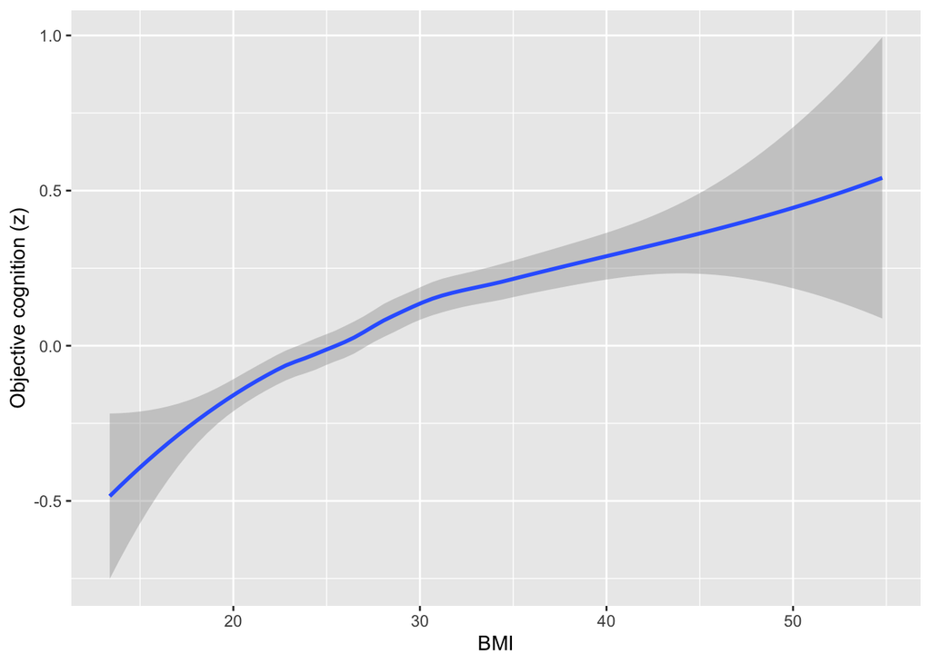

```r
w1_cc <- w1 |> drop_na(objective_cognition_z, bmi, age, sex_f, education_f, wealth_f)
ggplot(filter(w1_cc, bmi > 12, bmi < 55), aes(bmi, objective_cognition_z)) +
  geom_smooth(method = "loess") + labs(x = "BMI", y = "Objective cognition (z)")
```

```r
# YOUR TURN 2: is the association with continuous BMI non-linear?
# HINT: compare lm(... ~ bmi + ...) with lm(... ~ splines::ns(bmi, 3) + ...) using anova().
# Both models must use the same rows, so use data = w1_cc.
m4_lin <- lm(objective_cognition_z ~ bmi + age + sex_f + education_f + wealth_f, data = w1_cc)
m4_ns  <- lm(objective_cognition_z ~ splines::ns(bmi, 3) + age + sex_f + education_f + wealth_f, data = w1_cc)
anova(m4_lin, m4_ns)
```

```
## Analysis of Variance Table
##
## Model 1: objective_cognition_z ~ bmi + age + sex_f + education_f + wealth_f
## Model 2: objective_cognition_z ~ splines::ns(bmi, 3) + age + sex_f + education_f +
##     wealth_f
##   Res.Df    RSS Df Sum of Sq      F    Pr(>F)
## 1   4574 3158.1
## 2   4572 3142.4  2    15.667 11.397 1.155e-05 ***
## ---
## Signif. codes:  0 '***' 0.001 '**' 0.01 '*' 0.05 '.' 0.1 ' ' 1
```

```r
# Moderation by hypertension (HIV status is not in this file)
m4_int <- lm(objective_cognition_z ~ bmi_category_f * hypertension_diag + age + sex_f + education_f + wealth_f,
             data = w1)
anova(lm(objective_cognition_z ~ bmi_category_f + hypertension_diag + age + sex_f + education_f + wealth_f,
         data = model.frame(m4_int)), m4_int)
```

```
## Analysis of Variance Table
##
## Model 1: objective_cognition_z ~ bmi_category_f + hypertension_diag +
##     age + sex_f + education_f + wealth_f
## Model 2: objective_cognition_z ~ bmi_category_f * hypertension_diag +
##     age + sex_f + education_f + wealth_f
##   Res.Df    RSS Df Sum of Sq      F Pr(>F)
## 1   4538 3120.9
## 2   4535 3119.1  3    1.8099 0.8771 0.4521
```

*Interpretation:* Relative to normal BMI, underweight people score 0.20 SD lower (CI -0.31 to -0.09), overweight 0.13 SD higher and obese 0.20 SD higher. Within the observed range the association rises with BMI, but a spline fits better than a straight line (F = 11.4, p < 0.001): the curve is steep at low BMI and flattens higher up. Being thin at older ages is often a *consequence* of illness, food insecurity or early dementia (reverse causation), and being heavy can mark household resources. So this should not be read as “weight gain protects the brain”. Moderation by hypertension is null (interaction F = 0.88, p = 0.45).

# 7 Question 5: Are hypertension and diabetes associated with functional disability?

```r
w1_adl <- w1 |>
  mutate(comorbidity = factor(case_when(
    hypertension_diag == 0 & diabetes_diag == 0 ~ "Neither",
    hypertension_diag == 1 & diabetes_diag == 0 ~ "Hypertension only",
    hypertension_diag == 0 & diabetes_diag == 1 ~ "Diabetes only",
    hypertension_diag == 1 & diabetes_diag == 1 ~ "Both"),
    levels = c("Neither", "Hypertension only", "Diabetes only", "Both")))
w1_adl |> count(comorbidity) |> knitr::kable()
```

| comorbidity | n |
| --- | --- |
| Neither | 1564 |
| Hypertension only | 2514 |
| Diabetes only | 117 |
| Both | 438 |
| NA | 426 |

```r
adl_outcomes <- c("adls_walk", "adls_dress", "adls_bath", "adls_eat", "adls_toilet", "any_adl")
sapply(w1_adl[adl_outcomes], mean, na.rm = TRUE) |> round(3)   # prevalence: some are rare
```

```
##   adls_walk  adls_dress   adls_bath    adls_eat adls_toilet     any_adl
##       0.077       0.030       0.034       0.013       0.040       0.090
```

```r
# YOUR TURN 1: for each ADL outcome, fit a logistic model with comorbidity + confounders
# and keep the comorbidity odds ratios.
# HINT: same structure as the Q1c loop; use glm(f, family = binomial, data = w1_adl)
# and tidy(..., exponentiate = TRUE)
q5 <- lapply(adl_outcomes, function(y) {
  f <- reformulate(c("comorbidity", "age", "sex_f", "education_f", "wealth_f"), response = y)
  tidy(glm(f, family = binomial, data = w1_adl), conf.int = TRUE, exponentiate = TRUE) |>
    filter(grepl("comorbidity", term)) |> mutate(outcome = y)
}) |> bind_rows()

q5 |> select(outcome, term, estimate, conf.low, conf.high, p.value) |>
  mutate(across(where(is.numeric), ~ round(.x, 3))) |> knitr::kable()
```

| outcome | term | estimate | conf.low | conf.high | p.value |
| --- | --- | --- | --- | --- | --- |
| adls_walk | comorbidityHypertension only | 1.049 | 0.799 | 1.387 | 0.733 |
| adls_walk | comorbidityDiabetes only | 1.548 | 0.750 | 2.926 | 0.204 |
| adls_walk | comorbidityBoth | 2.072 | 1.424 | 2.999 | 0.000 |
| adls_dress | comorbidityHypertension only | 0.791 | 0.518 | 1.223 | 0.284 |
| adls_dress | comorbidityDiabetes only | 1.532 | 0.514 | 3.691 | 0.387 |
| adls_dress | comorbidityBoth | 1.827 | 1.035 | 3.165 | 0.034 |
| adls_bath | comorbidityHypertension only | 0.728 | 0.491 | 1.089 | 0.117 |
| adls_bath | comorbidityDiabetes only | 1.529 | 0.567 | 3.470 | 0.350 |
| adls_bath | comorbidityBoth | 1.231 | 0.687 | 2.136 | 0.471 |
| adls_eat | comorbidityHypertension only | 0.633 | 0.347 | 1.165 | 0.136 |
| adls_eat | comorbidityDiabetes only | 0.000 | 0.000 | 18137.721 | 0.981 |
| adls_eat | comorbidityBoth | 0.606 | 0.173 | 1.654 | 0.373 |
| adls_toilet | comorbidityHypertension only | 1.129 | 0.777 | 1.664 | 0.532 |
| adls_toilet | comorbidityDiabetes only | 0.778 | 0.185 | 2.209 | 0.681 |
| adls_toilet | comorbidityBoth | 2.192 | 1.322 | 3.600 | 0.002 |
| any_adl | comorbidityHypertension only | 1.001 | 0.779 | 1.294 | 0.992 |
| any_adl | comorbidityDiabetes only | 1.357 | 0.679 | 2.500 | 0.355 |
| any_adl | comorbidityBoth | 2.018 | 1.422 | 2.849 | 0.000 |

```r
# YOUR TURN 2: is having both conditions worse than expected from each alone?
# HINT: glm(any_adl ~ hypertension_diag * diabetes_diag + ..., family = binomial) and look at
# the interaction term.
m5_int <- glm(any_adl ~ hypertension_diag * diabetes_diag + age + sex_f + education_f + wealth_f,
              family = binomial, data = w1_adl)
show_glm(m5_int, "hypertension|diabetes")
```

| term | estimate | conf.low | conf.high | p.value |
| --- | --- | --- | --- | --- |
| hypertension_diag | 1.001 | 0.779 | 1.294 | 0.992 |
| diabetes_diag | 1.357 | 0.679 | 2.500 | 0.355 |
| hypertension_diag:diabetes_diag | 1.485 | 0.747 | 3.153 | 0.278 |

*Interpretation:* Hypertension alone shows no excess ADL difficulty (any ADL OR 1.00, 0.78 to 1.29). Diabetes alone is imprecise (only 117 people). Having **both** about doubles the odds of any ADL difficulty (OR 2.02, 1.42 to 2.85), with similar results for walking (2.07) and toileting (2.19) and a weaker one for dressing (1.83). Bathing and eating are not clearly raised. The eating row for “Diabetes only” is unusable (OR 0, CI to 18,000: no events in that cell). The interaction term (OR 1.49, 0.75 to 3.15) is underpowered: the data fit a combined effect at least as large as the two conditions added together, but can’t tell whether it is more than that. Comorbidity may also stand in for longer disease duration or complications.

# 8 Question 6: Which baseline factors predict cognitive decline?

Each factor’s interaction with `years` shows whether it predicts faster (negative) or slower (positive) change, in SD per year.

```r
# YOUR TURN: add the other baseline predictors inside the parentheses.
# Available: age10_bl, sex_f, education_f, asset_sd_bl, cesd_bl_z, htn_bl, dm_bl,
#            bmi_cat_bl_f, smoking_bl, alcohol_bl
m6 <- lmer(objective_cognition_z ~ years * (age10_bl + sex_f + education_f + asset_sd_bl + cesd_bl_z + htn_bl + dm_bl +
                                         bmi_cat_bl_f + smoking_bl + alcohol_bl) + (1 + years | prim_key),
           data = cog_long)
show_lmer(m6, "^years")
```

| term | estimate | conf.low | conf.high | p.value |
| --- | --- | --- | --- | --- |
| years | 0.084 | 0.070 | 0.098 | 0.000 |
| years:age10_bl | -0.013 | -0.018 | -0.008 | 0.000 |
| years:sex_fMale | -0.005 | -0.018 | 0.008 | 0.470 |
| years:education_fSome primary | -0.040 | -0.052 | -0.028 | 0.000 |
| years:education_fSome secondary | -0.039 | -0.057 | -0.020 | 0.000 |
| years:education_fSecondary+ | -0.082 | -0.105 | -0.060 | 0.000 |
| years:asset_sd_bl | 0.004 | -0.002 | 0.010 | 0.167 |
| years:cesd_bl_z | 0.009 | 0.003 | 0.014 | 0.002 |
| years:htn_bl | -0.009 | -0.021 | 0.002 | 0.101 |
| years:dm_bl | 0.010 | -0.007 | 0.027 | 0.233 |
| years:bmi_cat_bl_fUnderweight | 0.014 | -0.011 | 0.040 | 0.278 |
| years:bmi_cat_bl_fOverweight | -0.007 | -0.020 | 0.006 | 0.299 |
| years:bmi_cat_bl_fObese | -0.009 | -0.023 | 0.005 | 0.212 |
| years:smoking_bl | 0.005 | -0.011 | 0.022 | 0.511 |
| years:alcohol_bl | 0.010 | -0.002 | 0.023 | 0.106 |

*Interpretation:*

# 9 Question 7: Who is most resilient to cognitive decline?

**Approach A:** interactions with time, focused on possible protective factors.

```r
# YOUR TURN: same as m6, using education_f, asset_sd_bl, employment_bl_f, cesd_bl_z, htn_bl,
# dm_bl, bmi_bl inside the parentheses, and age10_bl + sex_f outside.
m7 <- lmer(objective_cognition_z ~ age10_bl + sex_f +
             years * (education_f + asset_sd_bl + employment_bl_f + cesd_bl_z + htn_bl + dm_bl + bmi_bl) +
             (1 + years | prim_key), data = cog_long)
show_lmer(m7, "^years")
```

| term | estimate | conf.low | conf.high | p.value |
| --- | --- | --- | --- | --- |
| years | 0.105 | 0.079 | 0.131 | 0.000 |
| years:education_fSome primary | -0.032 | -0.044 | -0.020 | 0.000 |
| years:education_fSome secondary | -0.025 | -0.042 | -0.008 | 0.005 |
| years:education_fSecondary+ | -0.064 | -0.086 | -0.043 | 0.000 |
| years:asset_sd_bl | 0.002 | -0.004 | 0.007 | 0.595 |
| years:employment_bl_fNot working | -0.005 | -0.020 | 0.010 | 0.495 |
| years:employment_bl_fHomemaker | -0.021 | -0.041 | 0.000 | 0.048 |
| years:cesd_bl_z | 0.008 | 0.002 | 0.013 | 0.007 |
| years:htn_bl | -0.014 | -0.025 | -0.003 | 0.014 |
| years:dm_bl | 0.007 | -0.010 | 0.024 | 0.442 |
| years:bmi_bl | -0.001 | -0.001 | 0.000 | 0.080 |

**Approach B:** among people with cognition at Waves 1 and 3, predict Wave 3 cognition from Wave 1 cognition, age, sex and follow-up time. People in the top 20% of residuals (doing better than expected) are labelled resilient.

```r
resil <- cog_long |>
  filter(wave %in% c(1, 3)) |>
  select(prim_key, wave, objective_cognition_z, years) |>
  pivot_wider(names_from = wave, values_from = c(objective_cognition_z, years)) |>
  rename(cog_w1 = objective_cognition_z_1, cog_w3 = objective_cognition_z_3, years_w3 = years_3) |>
  filter(!is.na(cog_w1), !is.na(cog_w3)) |>
  left_join(baseline, by = "prim_key")

m_resid <- lm(cog_w3 ~ cog_w1 + age_bl + I(age_bl^2) + sex_f + years_w3, data = resil)
resil$resid <- NA
resil$resid[as.numeric(rownames(model.frame(m_resid)))] <- resid(m_resid)
resil <- resil |> mutate(resilient = as.numeric(resid >= quantile(resid, 0.8, na.rm = TRUE)))
```

```r
# YOUR TURN 1: compare baseline characteristics of resilient people with everyone else
# HINT: group_by(resilient) |> summarise(n = n(), mean(asset_sd_bl, na.rm = TRUE), ...)
resil |> filter(!is.na(resilient)) |> group_by(resilient) |>
  summarise(n = n(), age = mean(age_bl, na.rm = TRUE), cog_w1 = mean(cog_w1, na.rm = TRUE),
            assets_sd = mean(asset_sd_bl, na.rm = TRUE), cesd_z = mean(cesd_bl_z, na.rm = TRUE),
            hypertension = mean(htn_bl, na.rm = TRUE), diabetes = mean(dm_bl, na.rm = TRUE),
            bmi = mean(bmi_bl, na.rm = TRUE)) |>
  mutate(across(where(is.numeric), ~ round(.x, 2))) |> knitr::kable()
```

| resilient | n | age | cog_w1 | assets_sd | cesd_z | hypertension | diabetes | bmi |
| --- | --- | --- | --- | --- | --- | --- | --- | --- |
| 0 | 2623 | 59.23 | 0.18 | -0.01 | -0.08 | 0.62 | 0.10 | 27.59 |
| 1 | 656 | 61.73 | 0.00 | 0.24 | -0.12 | 0.63 | 0.11 | 27.99 |

```r
resil |> filter(!is.na(resilient)) |> with(table(education_f, resilient)) |>
  prop.table(2) |> round(2) |> knitr::kable(caption = "Education by resilience (column %)")
```

Education by resilience (column %)

|  | 0 | 1 |
| --- | --- | --- |
| No formal | 0.42 | 0.36 |
| Some primary | 0.36 | 0.38 |
| Some secondary | 0.12 | 0.16 |
| Secondary+ | 0.10 | 0.10 |

```r
# YOUR TURN 2: logistic regression of resilient on the possible protective factors
m7b <- glm(resilient ~ education_f + asset_sd_bl + employment_bl_f + cesd_bl_z + htn_bl + dm_bl + bmi_bl,
           family = binomial, data = resil)
show_glm(m7b, "^(education|asset|employment|cesd|htn|dm|bmi)")
```

| term | estimate | conf.low | conf.high | p.value |
| --- | --- | --- | --- | --- |
| education_fSome primary | 1.136 | 0.918 | 1.405 | 0.240 |
| education_fSome secondary | 1.426 | 1.069 | 1.893 | 0.015 |
| education_fSecondary+ | 0.746 | 0.499 | 1.099 | 0.146 |
| asset_sd_bl | 1.253 | 1.141 | 1.376 | 0.000 |
| employment_bl_fNot working | 1.180 | 0.917 | 1.530 | 0.205 |
| employment_bl_fHomemaker | 1.143 | 0.794 | 1.636 | 0.469 |
| cesd_bl_z | 0.979 | 0.882 | 1.083 | 0.687 |
| htn_bl | 0.950 | 0.784 | 1.154 | 0.606 |
| dm_bl | 1.072 | 0.789 | 1.438 | 0.651 |
| bmi_bl | 1.005 | 0.991 | 1.018 | 0.510 |

*Interpretation:* In Approach B, wealth is the clearest marker of resilience. Each SD of assets raises the odds of doing better than expected by 25% (OR 1.25, 1.14 to 1.38), and some secondary education helps too (OR 1.43, 1.07 to 1.89), though not monotonically (secondary+ OR 0.75, CI 0.50 to 1.10). Depression, hypertension, diabetes, BMI and employment do not distinguish the groups. **The two approaches disagree on wealth:** in Approach A, wealth does not change the slope (0.002, p = 0.60), and education looks harmful there for the ceiling reasons above. Resilient people started *lower* at Wave 1 (0.00 vs 0.18 SD). Because one test score is measured with error, the residual approach still partly picks up people whose Wave 1 score was unluckily low (regression to the mean). Everyone here survived and stayed in to Wave 3, so the comparison group is already healthier than the cohort. Calling this “resilience” is generous: it is “outperforming one’s predicted score among survivors”.

# 10 Conclusions

- **Most promising: financial security.** Wealth has a graded link to cognitive level (richest vs poorest quintile +0.31 SD), and +0.5 SD of assets cuts predicted low cognition by about 2 percentage points (about 11% of cases). It also predicts outperforming one’s expected score by Wave 3. Hypertension treatment shows a similar modelled effect, but it rests entirely on a treated-vs-untreated contrast we don’t trust. Depression treatment gives about 0.6 points.
- **Biggest threats:** for wealth, lifelong confounding (childhood conditions and cognitive ability shape both wealth and test scores). For hypertension, healthy-user and access-to-care bias. For depression, reverse causation. For all change analyses, practice effects and dropout or death.
- **Other approaches:** education is the strongest correlate of cognitive level. Diabetes mainly changes *perceived* cognition, so patient-centred diabetes care matters. Comorbid hypertension plus diabetes doubles functional-limitation odds, which argues for joint chronic disease management.
- **A better study:** a regression discontinuity at pension eligibility age (60) comparing cognition just above and below the threshold, or a randomized cash transfer with cognitive follow-up.